# State of Salmon: Technical Documentation

### Central Coast

#### Chinook

For Central Coast Chinook, the PSC’s Chinook Technical Committee (CTC) reported escapement for two indicator stocks on the Central Coast: the Atnarko River and Rivers Inlet (Chinook Technical Committee 2025). Rivers Inlet is monitored “using an index of escapements to the Wannock, Kilbella, and Chuckwalla rivers” (Chinook Technical Committee 2025). Because monitoring of Central Coast Chinook reported in NuSEDS has recently declined, expansions from spawner surveys are unreliable. As such, in 2025 we moved to using a composite indicator equal to the sum of the Atnarko River (`Total esc.`) and Rivers Inlet index reported by the CTC in Appendix Table B3.

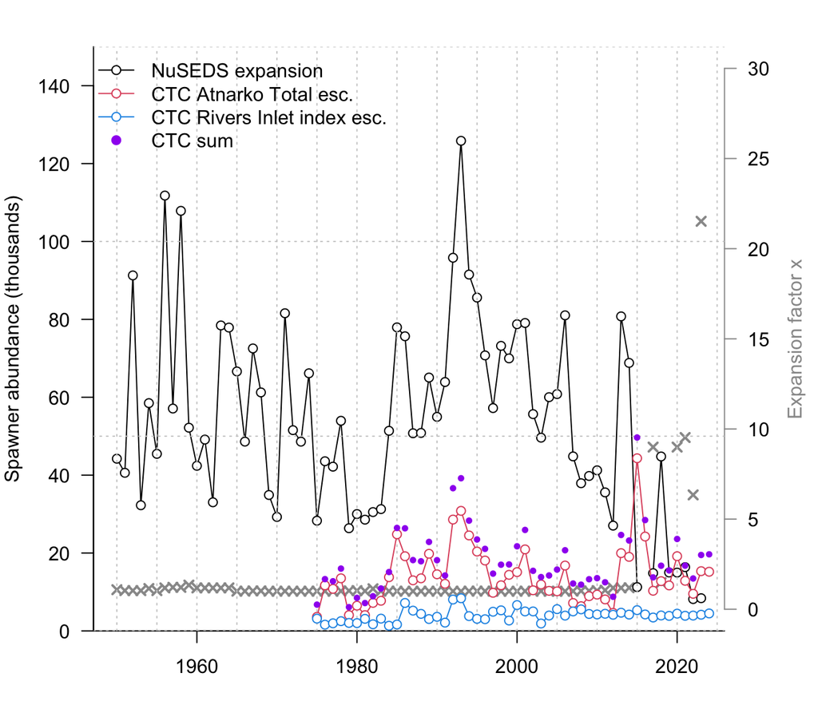

**Above:** Comparison of Chinook escapements on the Central Coast.

#### Steelhead

There are two spawner surveys for Steelhead trout on the Central Coast that we report in the Pacific Salmon Explorer. However, these surveys have been patchy through time with the most recent estimates from 2016. Therefore, spawner abundance and total return for Central Coast steelhead was considered unknown.

#### Other Species: Expansion Factors

Estimates of spawner abundance for all other salmon species on the Central Coast were expanded from available spawner surveys, as described below in Expansion Factors. Monitoring and reporting of observed spawners on the Central Coast has declined in recent decades, thus requiring larger expansion factors to arrive at an area-wide estimate that can be compared through time. As such, estimates of spawner abundance for the Central Coast over the past decade are more uncertain and should be interpreted with caution.